# Real-Time Credit Card Fraud Detection Using Machine Learning

## 1 Introduction

This report evaluates a machine learning approach for real-time credit card fraud detection in a banking setting. The purpose of the analysis is to determine whether transaction-level information available at the moment of purchase can be used to identify fraudulent activity quickly and accurately enough to support fraud prevention decisions. This is an important problem because fraud is costly to both banks and customers, but overly aggressive fraud detection can also block legitimate purchases and create customer frustration. The goal of the report is therefore not simply to maximize overall accuracy, but to find a model that balances catching fraudulent transactions with minimizing false alarms. The analysis uses labeled credit card transaction data containing transaction amount and 28 privacy-preserving principal component features, and the final model used in the notebook is a histogram-based gradient boosting classifier.

## 2 Methods

### 2.1 Imports

### 2.2 Data

The data for this lab originally comes from Kaggle. Citations for the data can be found on Kaggle.

- [Kaggle: Credit Card Fraud Detection](https://www.kaggle.com/datasets/mlg-ulb/creditcardfraud/) A brief description of the target variable is given.

> This dataset presents transactions that occurred in two days, where we have 492 frauds out of 284,807 transactions. The dataset is highly unbalanced, the positive class (frauds) account for 0.172% of all transactions.

Similarly, a brief description of the feature variables is given.

> It contains only numerical input variables which are the result of a PCA transformation. Unfortunately, due to confidentiality issues, we cannot provide the original features and more background information about the data. Features V1, V2, … V28 are the principal components obtained with PCA, the only features which have not been transformed with PCA are ‘Time’ and ‘Amount’. Feature ‘Time’ contains the seconds elapsed between each transaction and the first transaction in the dataset. The feature ‘Amount’ is the transaction Amount, this feature can be used for example-dependant cost-sensitive learning. Feature ‘Class’ is the response variable and it takes value 1 in case of fraud and 0 otherwise.

We are providing a modified version of this data for this lab.

Modifications include:

Removed the `Time` variable as it is misleading. Reduced the number of samples, while maintaining the number of fraudulent transactions. - The class imbalance is reduced, but the target is still highly imbalanced. Withheld some data that will be considered the production data. Renamed the target variable from `Class` to `Fraud`. Renamed the PCA transformed variables.

### 2.3 Data Dictionary

Each observation in the train, test, and (hidden) production data contains information about a particular credit card transaction.

#### 2.3.1 Variable Descriptions:

**`Fraud`**

- `[int64]` status of the transaction. `1` indicates a fraudulent transaction and `0` indicates not fraud, a genuine transaction.

**`Amount`**

- `[float64]` amount (in dollars) of the transaction.

**`PC01`** - **`PC28`**

- `[float64]` the 28 principal components that encode information such as location and type of purchase while preserving customer privacy.

### 2.4 Summary Statistics

#### 2.4.1 1. Number of samples/feature

```
# Samples: 54276
# Features: 29
```

#### 2.4.2 2. Fraud Balance

Figure 1 shows that fraudulent transactions are extremely rare compared with genuine transactions. This matters because a model could achieve very high accuracy by simply predicting every transaction as non-fraud. As a result, overall accuracy is not enough for this problem, and the analysis should focus more on metrics such as precision, recall, and F1 score.

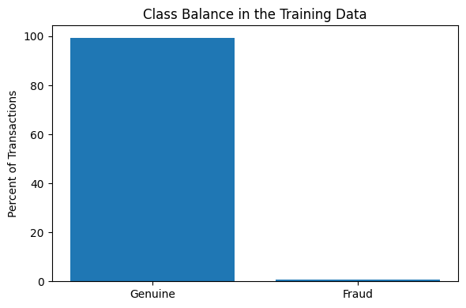

Figure 1: Class balance in the training data. Fraudulent transactions make up only a very small share of all transactions, highlighting the severe class imbalance in the fraud detection problem.

```
Fraud Balance:
   Label  Count  Proportion
0      0  53961    0.994196
1      1    315    0.005804
```

#### 2.4.3 3. Amount Summary Stats

```
Amount Summary:
                   Mean  Standard_Deviation  Median   Maximum
None          88.197903          241.535617   21.69  10199.44
0 (Genuine)   88.065104          241.451144   21.80  10199.44
1 (Fraud)    110.947016          254.978960    6.99   2125.87
```

### 2.5 Models

#### 2.5.1 Prepare Data for Machine Learning

Create the X and y variants of the data for use with sklearn:

Since fraudulent transactions typically constitute a minority of the data, we assign a higher weight to the positive class here, so that the model places greater emphasis on identifying fraudulent transactions.

The model ultimately used was the HistGradientBoostingClassifier. This model is well-suited for this problem because it can capture nonlinear relationships and interactions among features without requiring extensive manual feature engineering, and it performs exceptionally well on imbalanced datasets.

```
HistGradientBoostingClassifier(l2_regularization=1.0, learning_rate=0.03,
                               max_iter=400, random_state=42)
```

## 3 Results

```
Test precision: 0.9848
Test recall: 0.8228
Test F1: 0.8966
```

The final fraud detection model performed strongly on the held-out test data. It achieved a precision of 0.9848, a recall of 0.8228, and an F1 score of 0.8966. These results indicate that when the model predicts fraud, it is almost always correct, while still detecting a large majority of the fraudulent transactions in the test set.

The confusion matrix gives a clearer business interpretation of these results. Out of 79 fraudulent transactions in the test set, the model correctly identified 65 and missed 14. Out of 13,490 genuine transactions, it incorrectly flagged only 1. This means the model produced almost no false alarms while still catching most fraud cases. For a banking use case, that is a strong result because excessive false positives can interrupt valid customer purchases and damage trust.

The confusion matrix is the most useful visualization for communicating model performance because it directly shows the tradeoff between stopping fraud and avoiding disruption to legitimate users. As shown in Figure 2, the final model catches most fraudulent transactions while producing almost no false alarms on legitimate purchases.

```
array([[13489,     1],
       [   14,    65]])
```

### 3.1 Summary Figure

Figure 2 provides the clearest summary of the final model’s performance. The model correctly detected 65 fraudulent transactions and missed 14, while incorrectly flagging only 1 genuine transaction as fraud. This indicates that the model is very precise and creates very little unnecessary friction for legitimate customers, while still catching most fraud cases.

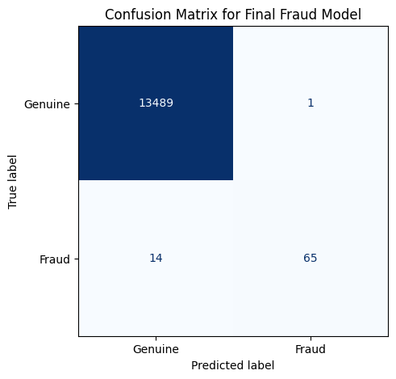

Figure 2: Confusion matrix for the final histogram-based gradient boosting fraud classifier on the test set. The model correctly identifies most fraudulent transactions while producing almost no false positives.

```
['fraud.joblib']
```

## 4 Discussion

Based on the test results, it is strong enough to be used as a real-time fraud screening tool that flags suspicious transactions for additional action. The biggest benefit of the model is that it catches a large share of fraud while creating almost no friction for legitimate customers. In the test set, only one genuine transaction was flagged incorrectly, which suggests the model is very conservative in a good way. For a loss minimization team, this is valuable because it reduces fraud losses without creating large volumes of unnecessary customer complaints.

At the same time, the model still missed 14 out of 79 fraudulent transactions, so it should not be treated as a perfect fraud blocker. That miss rate matters because in real banking settings, even a small number of undetected fraudulent transactions can translate into meaningful financial losses. In addition, the model was evaluated on a fixed test set, not on live production traffic. Fraud patterns change over time as bad actors adapt their behavior, so performance in deployment could be worse than performance in the notebook. This risk is especially important in fraud detection because data drift is common and attackers are not static.

Another limitation is interpretability. Most of the predictors are anonymized principal components rather than business-readable transaction features. That means the model may predict well, but it is harder to explain exactly why a specific transaction was flagged. This reduces transparency for stakeholders and can make model monitoring more difficult. There is also a modeling limitation in the fact that the fraud weighting choice was fixed at a specific value and the notebook evaluates only the final classification results. In practice, the bank would likely want to tune the decision threshold based on the business cost of false negatives versus false positives, rather than rely only on the default prediction cutoff.

Overall, I would recommend this model for real-world fraud screening, but only as a monitored decision-support layer.